# Final Project Report

Ellen Liu

12-13-2020

# Guiding Question: How gun-related violence affect the United States?

As the US is one of the few countries in which the right to bear arms is constitutionally protected. A consequence of this is that the level of gun violence is very high compared to other countries. For instance, America has six times as many firearm homicides as Canada, and nearly 16 times as many as Germany.

Based on Wikipedia, Gun violence in the US results in tens of thousands of deaths and injuries annually. In 2013, there were 73,505 nonfatal firearm injuries which included 11,208 homicides, 21,175 suicides, 505 deaths due to accidental or negligent discharge of a firearm, and 281 deaths due to firearms use with “undetermined intent”.

For this project, I have performed a deep exploration on this dataset of gun violence incidents reported in US by, Gun Violence Archive (GVA), a non-profit corporation formed in 2013 to provide free online public access to information about gun-related violence in the United States.

I want to perform this project with three perspective:

- Time
  - Yearly
  - Quarterly
  - Monthly
- Location
  - State
  - Density
- Type
  - Some popular cities vs. U.S.

And I expect these analysis will help us have a more comprehensive understanding about the gun violence in U.S. and take gun control more seriously.

## Data sources

### Primary data source: gun-violence-data_01-2013_03-2018.csv (73.1 MB)

I found this dataset from Kaggle website, it is a csv file called Gun Violence Data which contains data for all recorded gun violence incidents in the US between January 2013 and March 2018. [link](https://www.kaggle.com/jameslko/gun-violence-data)

The data was originally downloaded from gunviolencearchive.org. Gun Violence Archive (GVA) is a not for profit corporation formed in 2013. GVA will collect and check for accuracy, comprehensive information about gun-related violence in the U.S. and then post and disseminate it online.

They collected through 2013 to 2018 since all data is in this time range. And the reason they collected the data is to provide free online public access to accurate information about gun-related violence in the United States, and provide large and easily-accessible amounts of detailed data on gun violence.

```r
#load packages
library(dplyr)
library(tidyverse)

#import primary data source
Gun_violence <- read.csv("/Users/ellenus/Desktop/5th\ Semester/Stat\ 184/Final\ Project/gun-violence-data_01-2013_03-2018.csv", header = TRUE)

# Inspect data, show first 10 rows of the data
head(Gun_violence, 10)
```

|  | incident_id | date | state | city_or_county | address | n_killed | n_injured | congressional_district | gun_stolen | gun_type | incident_characteristics | location_description | n_guns_involved | notes | participant_age | participant_age_group | participant_gender | participant_relationship | participant_status | participant_type | state_house_district | state_senate_district |
| --- | --- | --- | --- | --- | --- | --- | --- | --- | --- | --- | --- | --- | --- | --- | --- | --- | --- | --- | --- | --- | --- | --- |
| 1 | 461105 | 1/1/13 | Pennsylvania | Mckeesport | 1506 Versailles Avenue and Coursin Street | 0 | 4 | 14 |  |  | Shot - Wounded/Injured\|\|Mass Shooting (4+ victims injured or killed excluding the subject/suspect/perpetrator, one location)\|\|Possession (gun(s) found during commission of other crimes)\|\|Possess… |  | NA | Julian Sims under investigation: Four Shot and Injured | 0::20 | 0::Adult 18+\|\|1::Adult 18+\|\|2::Adult 18+\|\|3::Adult 18+\|\|4::Adult 18+ | 0::Male\|\|1::Male\|\|3::Male\|\|4::Female |  | 0::Arrested\|\|1::Injured\|\|2::Injured\|\|3::Injured\|\|4::Injured | 0::Victim\|\|1::Victim\|\|2::Victim\|\|3::Victim\|\|4::Subject-Suspect | NA | NA |
| 2 | 460726 | 1/1/13 | California | Hawthorne | 13500 block of Cerise Avenue | 1 | 3 | 43 |  |  | Shot - Wounded/Injured\|\|Shot - Dead (murder, accidental, suicide)\|\|Mass Shooting (4+ victims injured or killed excluding the subject/suspect/perpetrator, one location)\|\|Gang involvement |  | NA | Four Shot; One Killed; Unidentified shooter in getaway car | 0::20 | 0::Adult 18+\|\|1::Adult 18+\|\|2::Adult 18+\|\|3::Adult 18+ | 0::Male |  | 0::Killed\|\|1::Injured\|\|2::Injured\|\|3::Injured | 0::Victim\|\|1::Victim\|\|2::Victim\|\|3::Victim\|\|4::Subject-Suspect | 62 | 35 |
| 3 | 478855 | 1/1/13 | Ohio | Lorain | 1776 East 28th Street | 1 | 3 | 9 | 0::Unknown\|\|1::Unknown | 0::Unknown\|\|1::Unknown | Shot - Wounded/Injured\|\|Shot - Dead (murder, accidental, suicide)\|\|Shots Fired - No Injuries\|\|Bar/club incident - in or around establishment | Cotton Club | 2 |  | 0::25\|\|1::31\|\|2::33\|\|3::34\|\|4::33 | 0::Adult 18+\|\|1::Adult 18+\|\|2::Adult 18+\|\|3::Adult 18+\|\|4::Adult 18+ | 0::Male\|\|1::Male\|\|2::Male\|\|3::Male\|\|4::Male |  | 0::Injured, Unharmed, Arrested\|\|1::Unharmed, Arrested\|\|2::Killed\|\|3::Injured\|\|4::Injured | 0::Subject-Suspect\|\|1::Subject-Suspect\|\|2::Victim\|\|3::Victim\|\|4::Victim | 56 | 13 |
| 4 | 478925 | 1/5/13 | Colorado | Aurora | 16000 block of East Ithaca Place | 4 | 0 | 6 |  |  | Shot - Dead (murder, accidental, suicide)\|\|Officer Involved Incident\|\|Officer Involved Shooting - subject/suspect/perpetrator killed\|\|Drug involvement\|\|Kidnapping/abductions/hostage\|\|Under t… |  | NA |  | 0::29\|\|1::33\|\|2::56\|\|3::33 | 0::Adult 18+\|\|1::Adult 18+\|\|2::Adult 18+\|\|3::Adult 18+ | 0::Female\|\|1::Male\|\|2::Male\|\|3::Male |  | 0::Killed\|\|1::Killed\|\|2::Killed\|\|3::Killed | 0::Victim\|\|1::Victim\|\|2::Victim\|\|3::Subject-Suspect | 40 | 28 |
| 5 | 478959 | 1/7/13 | North Carolina | Greensboro | 307 Mourning Dove Terrace | 2 | 2 | 6 | 0::Unknown\|\|1::Unknown | 0::Handgun\|\|1::Handgun | Shot - Wounded/Injured\|\|Shot - Dead (murder, accidental, suicide)\|\|Suicide^\|\|Murder/Suicide\|\|Attempted Murder/Suicide (one variable unsuccessful)\|\|Domestic Violence |  | 2 | Two firearms recovered. (Attempted) murder suicide - both succeeded in fulfilling an M/S and did not succeed, based on details. | 0::18\|\|1::46\|\|2::14\|\|3::47 | 0::Adult 18+\|\|1::Adult 18+\|\|2::Teen 12-17\|\|3::Adult 18+ | 0::Female\|\|1::Male\|\|2::Male\|\|3::Female | 3::Family | 0::Injured\|\|1::Injured\|\|2::Killed\|\|3::Killed | 0::Victim\|\|1::Victim\|\|2::Victim\|\|3::Subject-Suspect | 62 | 27 |
| 6 | 478948 | 1/7/13 | Oklahoma | Tulsa | 6000 block of South Owasso | 4 | 0 | 1 |  |  | Shot - Dead (murder, accidental, suicide)\|\|Home Invasion\|\|Home Invasion - Resident killed\|\|Mass Shooting (4+ victims injured or killed excluding the subject/suspect/perpetrator, one location)\|\… | Fairmont Terrace | NA |  | 0::23\|\|1::23\|\|2::33\|\|3::55 | 0::Adult 18+\|\|1::Adult 18+\|\|2::Adult 18+\|\|3::Adult 18+\|\|4::Adult 18+\|\|5::Adult 18+ | 0::Female\|\|1::Female\|\|2::Female\|\|3::Female\|\|4::Male\|\|5::Male |  | 0::Killed\|\|1::Killed\|\|2::Killed\|\|3::Killed\|\|4::Unharmed, Arrested\|\|5::Unharmed, Arrested | 0::Victim\|\|1::Victim\|\|2::Victim\|\|3::Victim\|\|4::Subject-Suspect\|\|5::Subject-Suspect | 72 | 11 |
| 7 | 479363 | 1/19/13 | New Mexico | Albuquerque | 2806 Long Lane | 5 | 0 | 1 | 0::Unknown\|\|1::Unknown | 0::22 LR\|\|1::223 Rem [AR-15] | Shot - Dead (murder, accidental, suicide)\|\|Mass Shooting (4+ victims injured or killed excluding the subject/suspect/perpetrator, one location)\|\|Domestic Violence |  | 2 |  | 0::51\|\|1::40\|\|2::9\|\|3::5\|\|4::2\|\|5::15 | 0::Adult 18+\|\|1::Adult 18+\|\|2::Child 0-11\|\|3::Child 0-11\|\|4::Child 0-11\|\|5::Teen 12-17 | 0::Male\|\|1::Female\|\|2::Male\|\|3::Female\|\|4::Female\|\|5::Male | 5::Family | 0::Killed\|\|1::Killed\|\|2::Killed\|\|3::Killed\|\|4::Killed\|\|5::Unharmed, Arrested | 0::Victim\|\|1::Victim\|\|2::Victim\|\|3::Victim\|\|4::Victim\|\|5::Subject-Suspect | 10 | 14 |
| 8 | 479374 | 1/21/13 | Louisiana | New Orleans | LaSalle Street and Martin Luther King Jr. Boulevard | 0 | 5 | 2 |  |  | Shot - Wounded/Injured\|\|Drive-by (car to street, car to car)\|\|Mass Shooting (4+ victims injured or killed excluding the subject/suspect/perpetrator, one location) |  | NA | Unprovoked drive-by results in multiple teens and young adults injured. No source with names or exact ages. |  |  | 0::Male\|\|1::Male\|\|2::Male\|\|3::Male\|\|4::Male |  | 0::Injured\|\|1::Injured\|\|2::Injured\|\|3::Injured\|\|4::Injured | 0::Victim\|\|1::Victim\|\|2::Victim\|\|3::Victim\|\|4::Victim\|\|5::Subject-Suspect | 93 | 5 |
| 9 | 479389 | 1/21/13 | California | Brentwood | 1100 block of Breton Drive | 0 | 4 | 9 |  |  | Shot - Wounded/Injured\|\|Drive-by (car to street, car to car)\|\|Mass Shooting (4+ victims injured or killed excluding the subject/suspect/perpetrator, one location)\|\|Gang involvement |  | NA | Perps were likely motivated by gang affliations |  | 0::Teen 12-17\|\|1::Teen 12-17\|\|2::Teen 12-17\|\|4::Adult 18+ | 0::Male\|\|1::Male\|\|2::Male\|\|3::Male\|\|4::Male |  | 0::Injured\|\|1::Injured\|\|2::Injured\|\|3::Injured\|\|4::Unharmed | 0::Victim\|\|1::Victim\|\|2::Victim\|\|3::Victim\|\|4::Subject-Suspect | 11 | 7 |
| 10 | 492151 | 1/23/13 | Maryland | Baltimore | 1500 block of W. Fayette St. | 1 | 6 | 7 |  |  | Shot - Wounded/Injured\|\|Shot - Dead (murder, accidental, suicide)\|\|Mass Shooting (4+ victims injured or killed excluding the subject/suspect/perpetrator, one location) |  | NA | Shooting occurred over illegal dice game; victim was killed as he sat on a stoop. Victim was not a participant in the game. | 0::15 | 0::Teen 12-17\|\|1::Adult 18+\|\|2::Adult 18+\|\|3::Adult 18+\|\|4::Adult 18+\|\|5::Adult 18+\|\|6::Adult 18+ | 0::Male |  | 0::Killed\|\|1::Injured\|\|2::Injured\|\|3::Injured\|\|4::Injured\|\|5::Injured\|\|6::Injured | 0::Victim\|\|1::Victim\|\|2::Victim\|\|3::Victim\|\|4::Victim\|\|5::Victim\|\|6::Victim | NA | 44 |

```r
NA
```

Each case in this dataset represents a gun-related incident occurred during January 2013 and March 2018 with the information of where, when, why each incident happened and background of people involved. And there are total of 239677 cases available.

```r
# total number of cases
nrow(Gun_violence)
```

```
[1] 239677
```

I have delete several variables(some URLs, latitude, longitude and name) from the original file before importing, which I think are not really useful. And the rest of 22 variables will somehow used in my project and following variables are mainly used: date, state, n-killed, n-injured, incident_characteristics. I will also add some new variables if necessary.

```r
# number of variables
ncol(Gun_violence)
```

```
[1] 22
```

### Supporting data: ZipGeography dataset from DataComputing package

As for this project, I want to perform some relationship between incidents and location, I choose the ZipGeography dataset from DataComputing package which includes the population for 53 states.

```r
# load package
library(DataComputing)

# inspect data
help( ZipGeography)
str(ZipGeography)
```

```
'data.frame':   42741 obs. of  13 variables:
 $ State         : Factor w/ 52 levels "","Massachusetts",..: 4 4 1 1 1 1 1 1 1 1 ...
 $ Population    : num  0 0 0 42042 55530 ...
 $ HousingUnits  : num  0 0 0 15590 21626 ...
 $ LandArea      : num  0.1 0 0 80.1 78.7 0 0 0 0 0 ...
 $ WaterArea     : num  46.3 170.3 4.7 0 0.1 ...
 $ CityName      : Factor w/ 18837 levels " ","Abington",..: 251 251 8 10 11 11 11 320 19 21 ...
 $ PostOfficeName: Factor w/ 18928 levels "Abington","Accord",..: 249 249 7 9 10 10 10 318 18 20 ...
 $ County        : Factor w/ 1909 levels "Adjuntas","Aguada",..: 89 89 1 2 3 3 3 58 6 93 ...
 $ AreaCode      : num  631 631 787 787 787 787 787 787 787 787 ...
 $ Timezone      : Factor w/ 13 levels " ","EST","EST+1",..: 2 2 3 3 3 3 3 3 3 3 ...
 $ Latitude      : num  40.9 40.9 18.2 18.4 18.5 ...
 $ Longitude     : num  -72.6 -72.6 -66.7 -67.2 -67.1 ...
 $ ZIP           : chr  "00501" "00544" "00601" "00602" ...
```

```r
head(ZipGeography, 10)
```

|  | State | Population | HousingUnits | LandArea | WaterArea | CityName | PostOfficeName | County | AreaCode | Timezone | Latitude | Longitude | ZIP |
| --- | --- | --- | --- | --- | --- | --- | --- | --- | --- | --- | --- | --- | --- |
| 1 | New York | 0 | 0 | 0.1 | 46.3 | Holtsville | Holtsville | Suffolk | 631 | EST | 40.92233 | -72.63708 | 00501 |
| 2 | New York | 0 | 0 | 0.0 | 170.3 | Holtsville | Holtsville | Suffolk | 631 | EST | 40.92233 | -72.63708 | 00544 |
| 3 |  | 0 | 0 | 0.0 | 4.7 | Adjuntas | Adjuntas | Adjuntas | 787 | EST+1 | 18.16527 | -66.72258 | 00601 |
| 4 |  | 42042 | 15590 | 80.1 | 0.0 | Aguada | Aguada | Aguada | 787 | EST+1 | 18.39310 | -67.18095 | 00602 |
| 5 |  | 55530 | 21626 | 78.7 | 0.1 | Aguadilla | Aguadilla | Aguadilla | 787 | EST+1 | 18.45591 | -67.14578 | 00603 |
| 6 |  | 0 | 0 | 0.0 | 20.8 | Aguadilla | Aguadilla | Aguadilla | 787 | EST+1 | 18.49352 | -67.13588 | 00604 |
| 7 |  | 0 | 0 | 0.0 | 11.8 | Aguadilla | Aguadilla | Aguadilla | 787 | EST+1 | 18.46516 | -67.14149 | 00605 |
| 8 |  | 0 | 0 | 0.0 | 1315.3 | Maricao | Maricao | Maricao | 787 | EST+1 | 18.17295 | -66.94411 | 00606 |
| 9 |  | 0 | 0 | 0.0 | 98.0 | Anasco | Anasco | Anasco | 787 | EST+1 | 18.28869 | -67.13970 | 00610 |
| 10 |  | 0 | 0 | 0.0 | 5.6 | Angeles | Angeles | Utuado | 787 | EST+1 | 18.27953 | -66.80217 | 00611 |

```r
ZipGeography
```

[output not shown]

[output cut: 990 more lines]

For this dataset, each case represents information about the location, area, and housing units in each ZIP code area. It contains 42741 cases and 13 variables. And I will mainly use the State, Population, City from it for this project. To better compute my analysis, I modified the dataset to only contain the variables I need and made two separate table focus on city and state.

```r
# population based on city
city_ZipGeography<-
      ZipGeography %>%
      group_by(State,CityName) %>%
      summarise(count= sum(Population,na.rm = TRUE)) %>%
      rename(population = count)
# population based on state
State_ZipGeography<-
      ZipGeography %>%
      group_by(State) %>%
      summarise(count= sum(Population,na.rm = TRUE)) %>%
      rename(population = count)
# explore both tables
city_ZipGeography
```

| State | CityName | population |
| --- | --- | --- |
|  | Adjuntas | 0 |
|  | Aguada | 42042 |
|  | Aguadilla | 55530 |
|  | Aguas Buenas | 0 |
|  | Aguirre | 0 |
|  | Aibonito | 0 |
|  | Anasco | 0 |
|  | Angeles | 0 |
|  | Arecibo | 0 |
|  | Arroyo | 0 |

[output cut: 990 more lines]

```r
State_ZipGeography
```

| State | population |
| --- | --- |
|  | 741752 |
| Massachusetts | 6349048 |
| New Hampshire | 1235735 |
| New York | 18974619 |
| Rhode Island | 1048319 |
| Maine | 1273094 |
| Vermont | 608822 |
| Connecticut | 3405565 |
| New Jersey | 8413990 |
| Pennsylvania | 12280587 |

[output cut: 43 more lines]

```r
NA
```

## Explore intuition related to the research question

### Date: Comparing number of incidents by year, quarter and month

For this first part I want to explore the relationship between time and number of incidents. Based on the analysis by year, quarter and month to see when the most incident occurs and see whether it’s increasing or decreasing.

```r
# load packages
library(tidyr)
library( lubridate )

#inspect data
str(Gun_violence)
```

```
'data.frame':   239677 obs. of  22 variables:
 $ incident_id             : int  461105 460726 478855 478925 478959 478948 479363 479374 479389 492151 ...
 $ date                    : chr  "1/1/13" "1/1/13" "1/1/13" "1/5/13" ...
 $ state                   : chr  "Pennsylvania" "California" "Ohio" "Colorado" ...
 $ city_or_county          : chr  "Mckeesport" "Hawthorne" "Lorain" "Aurora" ...
 $ address                 : chr  "1506 Versailles Avenue and Coursin Street" "13500 block of Cerise Avenue" "1776 East 28th Street" "16000 block of East Ithaca Place" ...
 $ n_killed                : int  0 1 1 4 2 4 5 0 0 1 ...
 $ n_injured               : int  4 3 3 0 2 0 0 5 4 6 ...
 $ congressional_district  : int  14 43 9 6 6 1 1 2 9 7 ...
 $ gun_stolen              : chr  "" "" "0::Unknown||1::Unknown" "" ...
 $ gun_type                : chr  "" "" "0::Unknown||1::Unknown" "" ...
 $ incident_characteristics: chr  "Shot - Wounded/Injured||Mass Shooting (4+ victims injured or killed excluding the subject/suspect/perpetrator, "| __truncated__ "Shot - Wounded/Injured||Shot - Dead (murder, accidental, suicide)||Mass Shooting (4+ victims injured or killed "| __truncated__ "Shot - …
 $ location_description    : chr  "" "" "Cotton Club" "" ...
 $ n_guns_involved         : int  NA NA 2 NA 2 NA 2 NA NA NA ...
 $ notes                   : chr  "Julian Sims under investigation: Four Shot and Injured" "Four Shot; One Killed; Unidentified shooter in getaway car" "" "" ...
 $ participant_age         : chr  "0::20" "0::20" "0::25||1::31||2::33||3::34||4::33" "0::29||1::33||2::56||3::33" ...
 $ participant_age_group   : chr  "0::Adult 18+||1::Adult 18+||2::Adult 18+||3::Adult 18+||4::Adult 18+" "0::Adult 18+||1::Adult 18+||2::Adult 18+||3::Adult 18+" "0::Adult 18+||1::Adult 18+||2::Adult 18+||3::Adult 18+||4::Adult 18+" "0::Adult 18+||1::Adult 18+||2::Adult 18+||3::Adult 18+" ...
 $ participant_gender      : chr  "0::Male||1::Male||3::Male||4::Female" "0::Male" "0::Male||1::Male||2::Male||3::Male||4::Male" "0::Female||1::Male||2::Male||3::Male" ...
 $ participant_relationship: chr  "" "" "" "" ...
 $ participant_status      : chr  "0::Arrested||1::Injured||2::Injured||3::Injured||4::Injured" "0::Killed||1::Injured||2::Injured||3::Injured" "0::Injured, Unharmed, Arrested||1::Unharmed, Arrested||2::Killed||3::Injured||4::Injured" "0::Killed||1::Killed||2::Killed||3::Killed" ...
 $ participant_type        : chr  "0::Victim||1::Victim||2::Victim||3::Victim||4::Subject-Suspect" "0::Victim||1::Victim||2::Victim||3::Victim||4::Subject-Suspect" "0::Subject-Suspect||1::Subject-Suspect||2::Victim||3::Victim||4::Victim" "0::Victim||1::Victim||2::Victim||3::Subject-Suspect" ...
 $ state_house_district    : int  NA 62 56 40 62 72 10 93 11 NA ...
 $ state_senate_district   : int  NA 35 13 28 27 11 14 5 7 44 ...
```

```r
# modify table: reform the date
Gun_violence_new <-
 Gun_violence %>%
   mutate(date = mdy(date)) %>% # make the date variable tidier
   mutate(year = lubridate::year(date),month = lubridate::month(date),day = lubridate::day(date)) # split the date variable to three different variable: year, month, date

#explore modified data table
Gun_violence_new
```

| incident_id | date | state | city_or_county | address | n_killed | n_injured | congressional_district | gun_stolen | gun_type | incident_characteristics | location_description | n_guns_involved | notes | participant_age | participant_age_group | participant_gender | participant_relationship | participant_status | participant_type | state_house_district | state_senate_district | year | month | day |
| --- | --- | --- | --- | --- | --- | --- | --- | --- | --- | --- | --- | --- | --- | --- | --- | --- | --- | --- | --- | --- | --- | --- | --- | --- |
| 461105 | 2013-01-01 | Pennsylvania | Mckeesport | 1506 Versailles Avenue and Coursin Street | 0 | 4 | 14 |  |  | Shot - Wounded/Injured\|\|Mass Shooting (4+ victims injured or killed excluding the subject/suspect/perpetrator, one location)\|\|Possession (gun(s) found during commission of other crimes)\|\|Possess… |  | NA | Julian Sims under investigation: Four Shot and Injured | 0::20 | 0::Adult 18+\|\|1::Adult 18+\|\|2::Adult 18+\|\|3::Adult 18+\|\|4::Adult 18+ | 0::Male\|\|1::Male\|\|3::Male\|\|4::Female |  | 0::Arrested\|\|1::Injured\|\|2::Injured\|\|3::Injured\|\|4::Injured | 0::Victim\|\|1::Victim\|\|2::Victim\|\|3::Victim\|\|4::Subject-Suspect | NA | NA | 2013 | 1 | 1 |
| 460726 | 2013-01-01 | California | Hawthorne | 13500 block of Cerise Avenue | 1 | 3 | 43 |  |  | Shot - Wounded/Injured\|\|Shot - Dead (murder, accidental, suicide)\|\|Mass Shooting (4+ victims injured or killed excluding the subject/suspect/perpetrator, one location)\|\|Gang involvement |  | NA | Four Shot; One Killed; Unidentified shooter in getaway car | 0::20 | 0::Adult 18+\|\|1::Adult 18+\|\|2::Adult 18+\|\|3::Adult 18+ | 0::Male |  | 0::Killed\|\|1::Injured\|\|2::Injured\|\|3::Injured | 0::Victim\|\|1::Victim\|\|2::Victim\|\|3::Victim\|\|4::Subject-Suspect | 62 | 35 | 2013 | 1 | 1 |
| 478855 | 2013-01-01 | Ohio | Lorain | 1776 East 28th Street | 1 | 3 | 9 | 0::Unknown\|\|1::Unknown | 0::Unknown\|\|1::Unknown | Shot - Wounded/Injured\|\|Shot - Dead (murder, accidental, suicide)\|\|Shots Fired - No Injuries\|\|Bar/club incident - in or around establishment | Cotton Club | 2 |  | 0::25\|\|1::31\|\|2::33\|\|3::34\|\|4::33 | 0::Adult 18+\|\|1::Adult 18+\|\|2::Adult 18+\|\|3::Adult 18+\|\|4::Adult 18+ | 0::Male\|\|1::Male\|\|2::Male\|\|3::Male\|\|4::Male |  | 0::Injured, Unharmed, Arrested\|\|1::Unharmed, Arrested\|\|2::Killed\|\|3::Injured\|\|4::Injured | 0::Subject-Suspect\|\|1::Subject-Suspect\|\|2::Victim\|\|3::Victim\|\|4::Victim | 56 | 13 | 2013 | 1 | 1 |
| 478925 | 2013-01-05 | Colorado | Aurora | 16000 block of East Ithaca Place | 4 | 0 | 6 |  |  | Shot - Dead (murder, accidental, suicide)\|\|Officer Involved Incident\|\|Officer Involved Shooting - subject/suspect/perpetrator killed\|\|Drug involvement\|\|Kidnapping/abductions/hostage\|\|Under t… |  | NA |  | 0::29\|\|1::33\|\|2::56\|\|3::33 | 0::Adult 18+\|\|1::Adult 18+\|\|2::Adult 18+\|\|3::Adult 18+ | 0::Female\|\|1::Male\|\|2::Male\|\|3::Male |  | 0::Killed\|\|1::Killed\|\|2::Killed\|\|3::Killed | 0::Victim\|\|1::Victim\|\|2::Victim\|\|3::Subject-Suspect | 40 | 28 | 2013 | 1 | 5 |
| 478959 | 2013-01-07 | North Carolina | Greensboro | 307 Mourning Dove Terrace | 2 | 2 | 6 | 0::Unknown\|\|1::Unknown | 0::Handgun\|\|1::Handgun | Shot - Wounded/Injured\|\|Shot - Dead (murder, accidental, suicide)\|\|Suicide^\|\|Murder/Suicide\|\|Attempted Murder/Suicide (one variable unsuccessful)\|\|Domestic Violence |  | 2 | Two firearms recovered. (Attempted) murder suicide - both succeeded in fulfilling an M/S and did not succeed, based on details. | 0::18\|\|1::46\|\|2::14\|\|3::47 | 0::Adult 18+\|\|1::Adult 18+\|\|2::Teen 12-17\|\|3::Adult 18+ | 0::Female\|\|1::Male\|\|2::Male\|\|3::Female | 3::Family | 0::Injured\|\|1::Injured\|\|2::Killed\|\|3::Killed | 0::Victim\|\|1::Victim\|\|2::Victim\|\|3::Subject-Suspect | 62 | 27 | 2013 | 1 | 7 |
| 478948 | 2013-01-07 | Oklahoma | Tulsa | 6000 block of South Owasso | 4 | 0 | 1 |  |  | Shot - Dead (murder, accidental, suicide)\|\|Home Invasion\|\|Home Invasion - Resident killed\|\|Mass Shooting (4+ victims injured or killed excluding the subject/suspect/perpetrator, one location)\|\… | Fairmont Terrace | NA |  | 0::23\|\|1::23\|\|2::33\|\|3::55 | 0::Adult 18+\|\|1::Adult 18+\|\|2::Adult 18+\|\|3::Adult 18+\|\|4::Adult 18+\|\|5::Adult 18+ | 0::Female\|\|1::Female\|\|2::Female\|\|3::Female\|\|4::Male\|\|5::Male |  | 0::Killed\|\|1::Killed\|\|2::Killed\|\|3::Killed\|\|4::Unharmed, Arrested\|\|5::Unharmed, Arrested | 0::Victim\|\|1::Victim\|\|2::Victim\|\|3::Victim\|\|4::Subject-Suspect\|\|5::Subject-Suspect | 72 | 11 | 2013 | 1 | 7 |
| 479363 | 2013-01-19 | New Mexico | Albuquerque | 2806 Long Lane | 5 | 0 | 1 | 0::Unknown\|\|1::Unknown | 0::22 LR\|\|1::223 Rem [AR-15] | Shot - Dead (murder, accidental, suicide)\|\|Mass Shooting (4+ victims injured or killed excluding the subject/suspect/perpetrator, one location)\|\|Domestic Violence |  | 2 |  | 0::51\|\|1::40\|\|2::9\|\|3::5\|\|4::2\|\|5::15 | 0::Adult 18+\|\|1::Adult 18+\|\|2::Child 0-11\|\|3::Child 0-11\|\|4::Child 0-11\|\|5::Teen 12-17 | 0::Male\|\|1::Female\|\|2::Male\|\|3::Female\|\|4::Female\|\|5::Male | 5::Family | 0::Killed\|\|1::Killed\|\|2::Killed\|\|3::Killed\|\|4::Killed\|\|5::Unharmed, Arrested | 0::Victim\|\|1::Victim\|\|2::Victim\|\|3::Victim\|\|4::Victim\|\|5::Subject-Suspect | 10 | 14 | 2013 | 1 | 19 |
| 479374 | 2013-01-21 | Louisiana | New Orleans | LaSalle Street and Martin Luther King Jr. Boulevard | 0 | 5 | 2 |  |  | Shot - Wounded/Injured\|\|Drive-by (car to street, car to car)\|\|Mass Shooting (4+ victims injured or killed excluding the subject/suspect/perpetrator, one location) |  | NA | Unprovoked drive-by results in multiple teens and young adults injured. No source with names or exact ages. |  |  | 0::Male\|\|1::Male\|\|2::Male\|\|3::Male\|\|4::Male |  | 0::Injured\|\|1::Injured\|\|2::Injured\|\|3::Injured\|\|4::Injured | 0::Victim\|\|1::Victim\|\|2::Victim\|\|3::Victim\|\|4::Victim\|\|5::Subject-Suspect | 93 | 5 | 2013 | 1 | 21 |
| 479389 | 2013-01-21 | California | Brentwood | 1100 block of Breton Drive | 0 | 4 | 9 |  |  | Shot - Wounded/Injured\|\|Drive-by (car to street, car to car)\|\|Mass Shooting (4+ victims injured or killed excluding the subject/suspect/perpetrator, one location)\|\|Gang involvement |  | NA | Perps were likely motivated by gang affliations |  | 0::Teen 12-17\|\|1::Teen 12-17\|\|2::Teen 12-17\|\|4::Adult 18+ | 0::Male\|\|1::Male\|\|2::Male\|\|3::Male\|\|4::Male |  | 0::Injured\|\|1::Injured\|\|2::Injured\|\|3::Injured\|\|4::Unharmed | 0::Victim\|\|1::Victim\|\|2::Victim\|\|3::Victim\|\|4::Subject-Suspect | 11 | 7 | 2013 | 1 | 21 |
| 492151 | 2013-01-23 | Maryland | Baltimore | 1500 block of W. Fayette St. | 1 | 6 | 7 |  |  | Shot - Wounded/Injured\|\|Shot - Dead (murder, accidental, suicide)\|\|Mass Shooting (4+ victims injured or killed excluding the subject/suspect/perpetrator, one location) |  | NA | Shooting occurred over illegal dice game; victim was killed as he sat on a stoop. Victim was not a participant in the game. | 0::15 | 0::Teen 12-17\|\|1::Adult 18+\|\|2::Adult 18+\|\|3::Adult 18+\|\|4::Adult 18+\|\|5::Adult 18+\|\|6::Adult 18+ | 0::Male |  | 0::Killed\|\|1::Injured\|\|2::Injured\|\|3::Injured\|\|4::Injured\|\|5::Injured\|\|6::Injured | 0::Victim\|\|1::Victim\|\|2::Victim\|\|3::Victim\|\|4::Victim\|\|5::Victim\|\|6::Victim | NA | 44 | 2013 | 1 | 23 |

[output cut: 990 more lines]

```r
str(Gun_violence_new)
```

```
'data.frame':   239677 obs. of  25 variables:
 $ incident_id             : int  461105 460726 478855 478925 478959 478948 479363 479374 479389 492151 ...
 $ date                    : Date, format: "2013-01-01" "2013-01-01" "2013-01-01" "2013-01-05" ...
 $ state                   : chr  "Pennsylvania" "California" "Ohio" "Colorado" ...
 $ city_or_county          : chr  "Mckeesport" "Hawthorne" "Lorain" "Aurora" ...
 $ address                 : chr  "1506 Versailles Avenue and Coursin Street" "13500 block of Cerise Avenue" "1776 East 28th Street" "16000 block of East Ithaca Place" ...
 $ n_killed                : int  0 1 1 4 2 4 5 0 0 1 ...
 $ n_injured               : int  4 3 3 0 2 0 0 5 4 6 ...
 $ congressional_district  : int  14 43 9 6 6 1 1 2 9 7 ...
 $ gun_stolen              : chr  "" "" "0::Unknown||1::Unknown" "" ...
 $ gun_type                : chr  "" "" "0::Unknown||1::Unknown" "" ...
 $ incident_characteristics: chr  "Shot - Wounded/Injured||Mass Shooting (4+ victims injured or killed excluding the subject/suspect/perpetrator, "| __truncated__ "Shot - Wounded/Injured||Shot - Dead (murder, accidental, suicide)||Mass Shooting (4+ victims injured or killed "| __truncated__ "Shot - …
 $ location_description    : chr  "" "" "Cotton Club" "" ...
 $ n_guns_involved         : int  NA NA 2 NA 2 NA 2 NA NA NA ...
 $ notes                   : chr  "Julian Sims under investigation: Four Shot and Injured" "Four Shot; One Killed; Unidentified shooter in getaway car" "" "" ...
 $ participant_age         : chr  "0::20" "0::20" "0::25||1::31||2::33||3::34||4::33" "0::29||1::33||2::56||3::33" ...
 $ participant_age_group   : chr  "0::Adult 18+||1::Adult 18+||2::Adult 18+||3::Adult 18+||4::Adult 18+" "0::Adult 18+||1::Adult 18+||2::Adult 18+||3::Adult 18+" "0::Adult 18+||1::Adult 18+||2::Adult 18+||3::Adult 18+||4::Adult 18+" "0::Adult 18+||1::Adult 18+||2::Adult 18+||3::Adult 18+" ...
 $ participant_gender      : chr  "0::Male||1::Male||3::Male||4::Female" "0::Male" "0::Male||1::Male||2::Male||3::Male||4::Male" "0::Female||1::Male||2::Male||3::Male" ...
 $ participant_relationship: chr  "" "" "" "" ...
 $ participant_status      : chr  "0::Arrested||1::Injured||2::Injured||3::Injured||4::Injured" "0::Killed||1::Injured||2::Injured||3::Injured" "0::Injured, Unharmed, Arrested||1::Unharmed, Arrested||2::Killed||3::Injured||4::Injured" "0::Killed||1::Killed||2::Killed||3::Killed" ...
 $ participant_type        : chr  "0::Victim||1::Victim||2::Victim||3::Victim||4::Subject-Suspect" "0::Victim||1::Victim||2::Victim||3::Victim||4::Subject-Suspect" "0::Subject-Suspect||1::Subject-Suspect||2::Victim||3::Victim||4::Victim" "0::Victim||1::Victim||2::Victim||3::Subject-Suspect" ...
 $ state_house_district    : int  NA 62 56 40 62 72 10 93 11 NA ...
 $ state_senate_district   : int  NA 35 13 28 27 11 14 5 7 44 ...
 $ year                    : num  2013 2013 2013 2013 2013 ...
 $ month                   : num  1 1 1 1 1 1 1 1 1 1 ...
 $ day                     : int  1 1 1 5 7 7 19 21 21 23 ...
```

#### Yearly incidents

```r
# create yearly incidents table of the U.S. from 2014-2017
yearly <-
  Gun_violence_new %>%
  filter(year!= 2013, year != 2018)  %>% # exclude 2013 and 2018 since the data are incomplete
  group_by(year) %>%
  summarise(yearly= n()) %>%
  mutate(year_average = mean(yearly)) # compute new variable of average number of incidents of 4 years
yearly
```

| year | yearly | year_average |
| --- | --- | --- |
| 2014 | 51854 | 56399.25 |
| 2015 | 53579 | 56399.25 |
| 2016 | 58763 | 56399.25 |
| 2017 | 61401 | 56399.25 |

```r
NA
```

##### Yearly bar charts

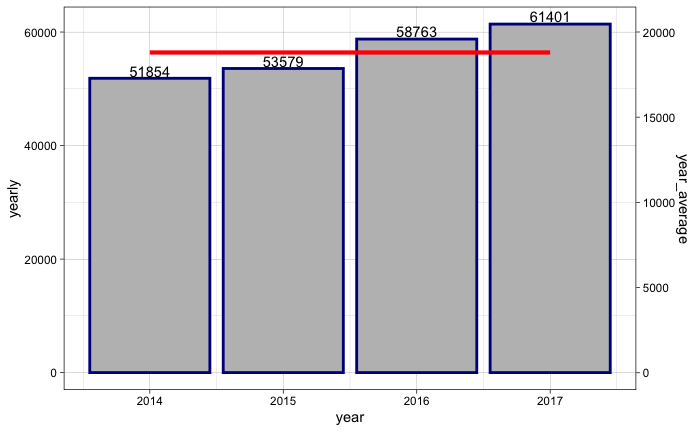

```r
# plot yearly graph with average line
ggplot(yearly) +
  geom_col(aes(x = year, y = yearly), size = 1, color = "darkblue", fill = "grey") +
  geom_line(aes(x = year, y = year_average), size = 1.5, color="red", group = 1) +
  scale_y_continuous(sec.axis = sec_axis(~./3, name = "year_average"))+geom_text(aes(x = year, y = yearly, label = yearly), vjust = -0.2)+theme_linedraw()
```

It seems as if most incidents in 2013 were not recorded. And 2018 only has first quarter recorded. So I only used the rest four years. And is obvious that number of incidents are **increasing** as year passing.

#### Quarterly incidents

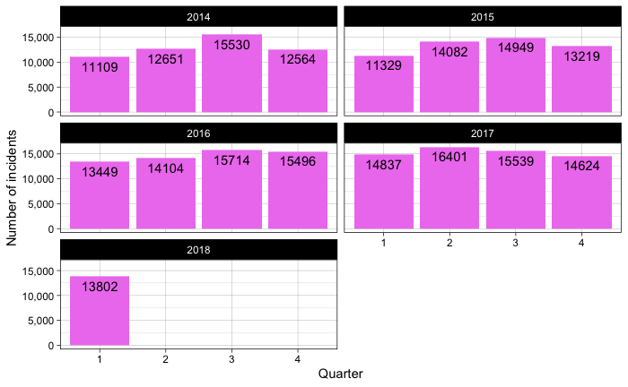

```r
# load package
library(ggplot2)

# Get quarter as new variable
Gun_violence_new$quarter <- quarter(Gun_violence_new$date)

# create yearly incidents table of the U.S. from 2014-2017
quarterly <-
  Gun_violence_new %>%
  filter(year!=2013) %>% #exclude 2013 since the data is incomplete
  select(year, quarter) %>%
  group_by(year) %>%
  count(quarter) %>%

  # plot quarterly bargraph and set each year as a facet
  ggplot(aes(x=as.factor(quarter), y=n)) + geom_bar(stat='identity', fill = "violet") + scale_y_continuous(labels=comma) +   facet_grid(.~year) + labs(x='Quarter', y='Number of incidents')+geom_text(aes(label = n), vjust = 1.5)+theme_linedraw() + facet_wrap(.~year,ncol=2)


quarterly
```

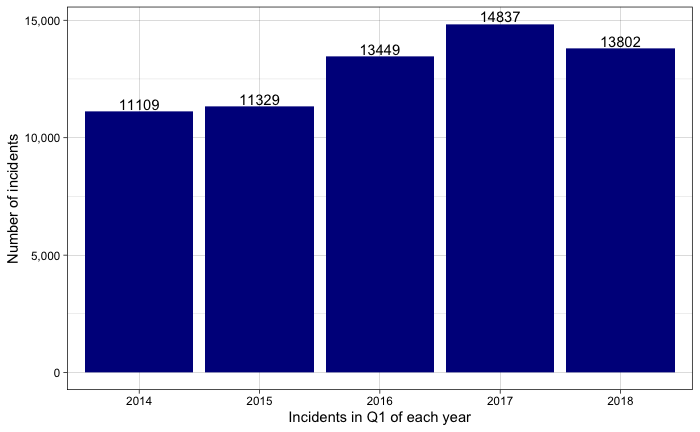

```r
#compare quarter 1 for each year
first_quarter <-
  Gun_violence_new %>%
  filter(year!=2013 & quarter==1) %>% # since 2018 only have quarter 1 recorded and 2013 does not have data
  select(year, quarter) %>%
        group_by(year) %>%
        count(quarter) %>%
  # plot first quarter bargraph
        ggplot(aes(x=as.factor(year), y=n)) + geom_bar(stat='identity',fill = "darkblue") + scale_y_continuous(labels=comma) + labs(x='Incidents in Q1 of each year', y='Number of incidents') + geom_text(aes(label = n), vjust = -0.2) + theme_linedraw()

first_quarter
```

Since 2018 only have quarter 1 recorded, I try to compare only the first quarter for each year. The second graph shows that Q1 2018 holds less incidents than Q1 2017. This could be seen as a **cautiously positive sign**. However, one should realize that this number is still very high when compared to other countries (relatively).

#### Monthly incidents

```r
# load package
library(scales)

#create monthly table  for each year
monthly1<-
Gun_violence_new %>%
  filter(year!= 2013)  %>%
  group_by(year,month) %>%
  summarise(monthly= n())
# get monthly average for each month
monthly2<-
Gun_violence_new %>%
  filter(year!= 2013, year != 2018)  %>%
  group_by(month) %>%
  summarise(months= n())  %>%
  mutate(month_average = months/4) # compute new variable of average number of incidents of each month
# left join two tables together
monthly<-
  monthly1 %>%
left_join(monthly2, by = c("month"= "month"))

monthly
```

| year | month | monthly | months | month_average |
| --- | --- | --- | --- | --- |
| 2014 | 1 | 4395 | 18150 | 4537.50 |
| 2014 | 2 | 3045 | 14705 | 3676.25 |
| 2014 | 3 | 3669 | 17869 | 4467.25 |
| 2014 | 4 | 3891 | 18611 | 4652.75 |
| 2014 | 5 | 4320 | 19903 | 4975.75 |
| 2014 | 6 | 4440 | 18724 | 4681.00 |
| 2014 | 7 | 5219 | 21092 | 5273.00 |
| 2014 | 8 | 5259 | 21012 | 5253.00 |
| 2014 | 9 | 5052 | 19628 | 4907.00 |
| 2014 | 10 | 4915 | 19868 | 4967.00 |

[output cut: 41 more lines]

##### Monthly bar charts

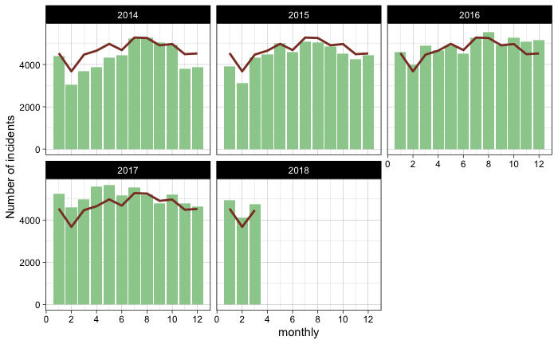

```r
# plot monthly graph with average line for each month
monthly%>%
ggplot(aes(x=month, y=monthly)) + geom_bar(stat='identity',fill="darkseagreen3")  + facet_wrap(.~year,ncol=3) + labs(x='monthly', y='Number of incidents')+scale_x_continuous(breaks = pretty_breaks())+theme_linedraw() +geom_line(aes(x = month, y = month_average), size = 1, color="coral4", group = 1)
```

The analysis of quarters shows that more incidents occur in the warmer spring and summer periods. This seems worth diving into a little deeper.

The most visible ‘seasonality’ effect seems to me that the colder months seem to have less incidents. November, December, and February are the 3 months with the lowest number of incidents (February also only has 28 days of course). The exception seems to be January, which is worth investigating later on. My first idea is that possibly incidents on new years eve contribute to January having a high number of incidents.The other peak is the July/August period. I think that the fact that many people go on holidays in this period is the most likely explanation.

And even we observe that 2018 first quarter is slightly less than 2017, we can still see that all three month are still high than the monthly average, so we still need to take this seriously.

### Location: Comparing number of incidents by state and city.

In the second part of observation, I want to know the relationship between the location and incidents to see where most incidents happened and try to conclude some possible reasons.

#### Top 10 states with most incidents

```r
# the top 10 states with the most gun-related violence during the period
top10State <-
  Gun_violence %>%
  group_by(state) %>%
  summarise(case_count= n()) %>%
   arrange(desc(case_count)) %>% # make data in descending order
   head(10)
top10State
```

| state | case_count |
| --- | --- |
| Illinois | 17556 |
| California | 16306 |
| Florida | 15029 |
| Texas | 13577 |
| Ohio | 10244 |
| New York | 9712 |
| Pennsylvania | 8929 |
| Georgia | 8925 |
| North Carolina | 8739 |
| Louisiana | 8103 |

##### top10State bar charts

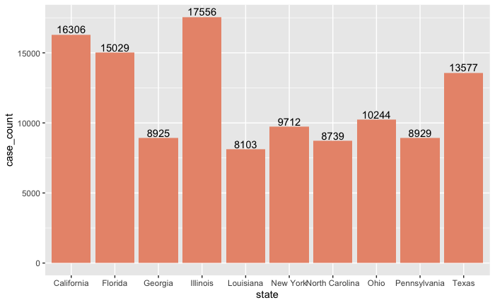

```r
#
ggplot(data=top10State, aes(x=state, y=case_count)) + geom_bar(stat="identity",fill="darksalmon") + geom_text(aes(label = case_count), vjust = -0.2)
```

For this first graph, I just simply compute the first 10 states with most incidents between 2013 and 2018. And we can see that Pennsylvania is also in the top 10. However, these numbers should be related to the **numbers of inhabitants** to get a good view of the relative numbers of incidents. For instance, California is a state with a very large population. Therefore, it is no surprise to see California as the number two in absolute numbers.

```r
#Incidents of each State in descending order
topState <-
  Gun_violence %>%
  group_by(state) %>%
  summarise(case_count= n()) %>%
   arrange(desc(case_count))
#Incidents relative to the State population size
crimedensity<-
  topState %>%
left_join(State_ZipGeography, by = c("state"= "State")) %>%
  mutate(per_million=case_count/(population/1000000)) # create a new variable that show incidents per million inhabintants

crimedensity
```

| state | case_count | population | per_million |
| --- | --- | --- | --- |
| Illinois | 17556 | 12419037 | 1413.6362 |
| California | 16306 | 33864430 | 481.5082 |
| Florida | 15029 | 15979631 | 940.5098 |
| Texas | 13577 | 20835778 | 651.6195 |
| Ohio | 10244 | 11353002 | 902.3164 |
| New York | 9712 | 18974619 | 511.8416 |
| Pennsylvania | 8929 | 12280587 | 727.0825 |
| Georgia | 8925 | 8185503 | 1090.3423 |
| North Carolina | 8739 | 8049254 | 1085.6907 |
| Louisiana | 8103 | 4465946 | 1814.3972 |

[output cut: 41 more lines]

##### Incident desdity bar charts

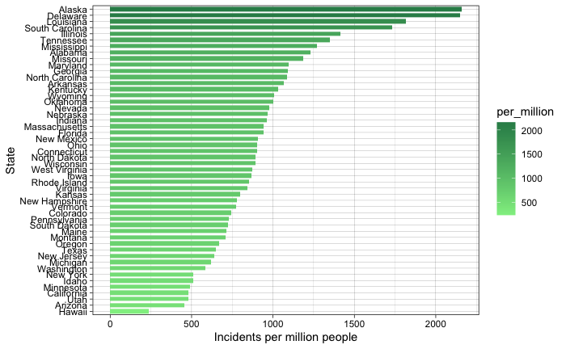

```r
# Plot bar charts of incidents density graph
crimedensity %>%
  filter(state!="District of Columbia")%>% # filter out District of Columbia since it's a outlier
  ggplot(aes(y=reorder(state, per_million), x=per_million, fill=per_million, text=state,width=.7))+geom_bar(stat='identity')+theme(legend.position="none")+labs(x='Incidents per million people', y='State')+theme_linedraw()+ scale_fill_gradient(low="lightgreen", high="seagreen4")
```

As I indicated earlier that incident numbers should be related to the numbers of inhabitants, so for this graph, I join the two table so we can compare incident number with population. *Note: actually the District of Columbia came out as the state with the highest incidents rate. But it’s not really a state and it creates a outlier, so I choose to eliminate it for this graph.*

In the figure above, you can see that the enriched data, which are related to the population of each state, paint a very different picture. As the numbers of incidents are related to the population sizes, these numbers now represent ‘real’ gun danger levels. To show this visually, I have used color codes. Dark green means a high danger level in terms of relative numbers of incidents, and light green means that a state is relatively safe.

Now, Alaska, Louisiana and Delaware are showing the highest relative incident numbers. Hawaii seems the safest state to live in , and the large state of California drops from second state in terms of absolute incidents to a lower position when corrected for the large population.

```r
install.packages("usmap")
```

[output not shown]

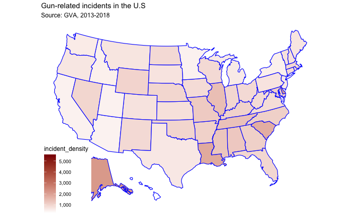

```r
#load package
library(usmap)

#Graph gun-related incidents in the U.S map
plot_usmap(data = crimedensity,values="per_million",color="blue") +
  labs(title = "Gun-related incidents in the U.S",
       subtitle = "Source: GVA, 2013-2018") + scale_fill_continuous(low="white",high="darkred",name="incident_density",label=scales::comma)
```

```r
  theme(legend.position = "right")
```

[output not shown]

To make the visualization much clearer, I compute a map so that we can see that per million inhabitants, states at south-east part of the U.S. tend to have more incidents.

#### Victims by State

```r
#add new variable: victims
Gun_violence_new$victims <- Gun_violence_new$n_killed + Gun_violence_new$n_injured

Victims1 <-
  Gun_violence_new %>%
  group_by(state) %>%
  summarize(sumVic=sum(victims), sumInj=sum(n_injured), sumDeath=sum(n_killed), PercDeath=round(sumDeath/sumVic,2), sumIncidents=n(), vicPerInc=round(sumVic/sumIncidents,2))
victims<-
  Victims1 %>%
left_join(State_ZipGeography, by = c("state"= "State"))
head(victims)
```

| state | sumVic | sumInj | sumDeath | PercDeath | sumIncidents | vicPerInc | population |
| --- | --- | --- | --- | --- | --- | --- | --- |
| Alabama | 4878 | 2998 | 1880 | 0.39 | 5471 | 0.89 | 4446124 |
| Alaska | 592 | 325 | 267 | 0.45 | 1349 | 0.44 | 624992 |
| Arizona | 2190 | 1096 | 1094 | 0.50 | 2328 | 0.94 | 5109325 |
| Arkansas | 2120 | 1347 | 773 | 0.36 | 2842 | 0.75 | 2668599 |
| California | 13206 | 7644 | 5562 | 0.42 | 16306 | 0.81 | 33864430 |
| Colorado | 1929 | 1133 | 796 | 0.41 | 3201 | 0.60 | 4301097 |

As you can see in the table above, Alaska actually has a relatively low number of victims per incident (0.44). However, as shown in the density graph, Alaska has the highest density.

##### Graph of relationship between state populatio and victim per incident

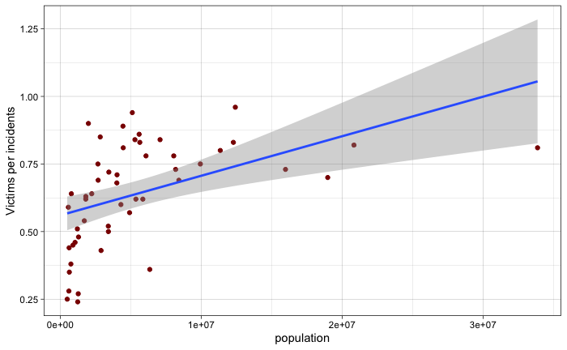

```r
# Scatter plot with regression line
victims %>%
ggplot(aes(x=population, y=vicPerInc)) + geom_point(stat='identity',color="darkred") +
        labs(x='population', y='Victims per incidents') +geom_smooth(method=lm)+theme_linedraw()
```

In the graph above, which uses the scatter plot with regression line, you can see that there is positive relationship between the number of victims relative to the population size. This is no surprise, as the state has higher population tend to have more incidents and ranks high regarding the victims per incident ratio.